# 06-merge-samples-w-taxonomy

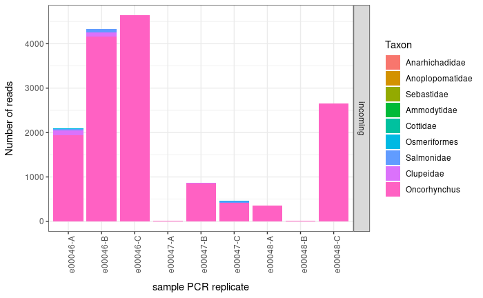

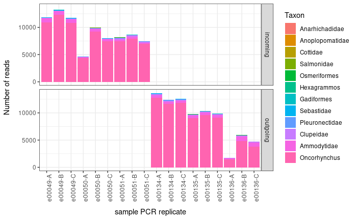

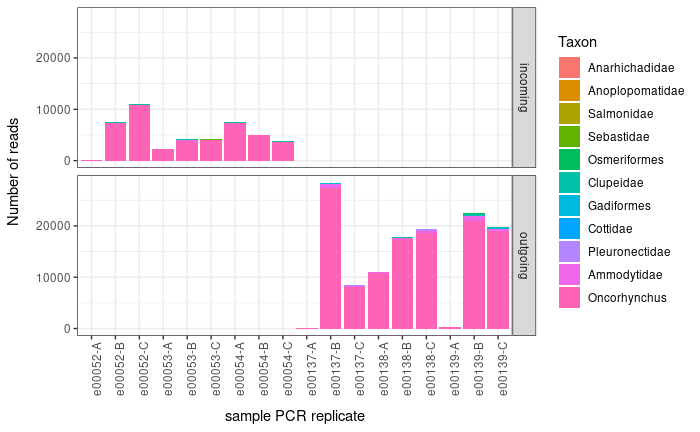

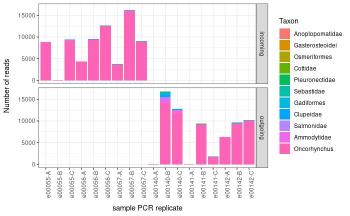

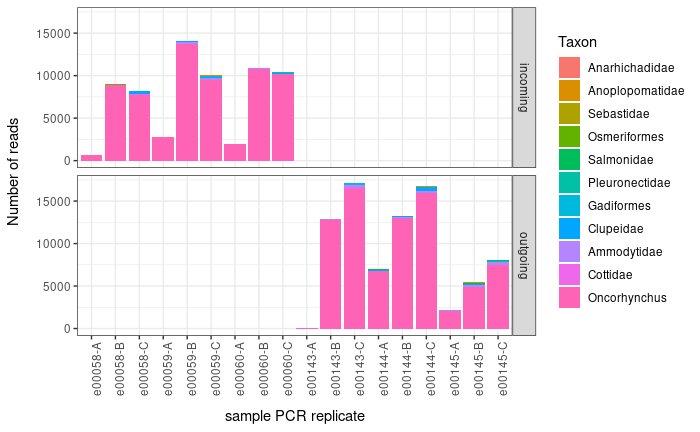

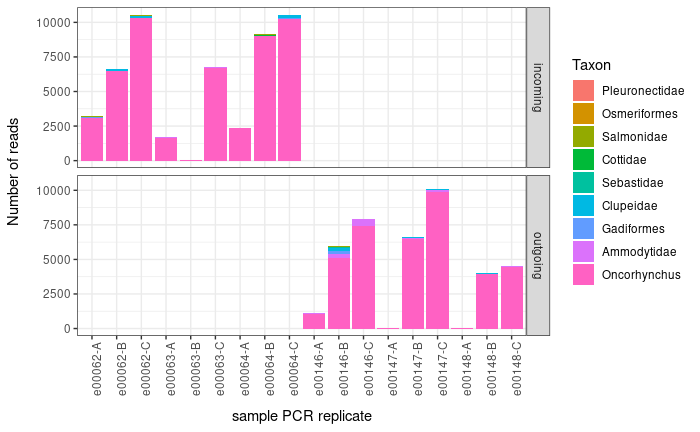

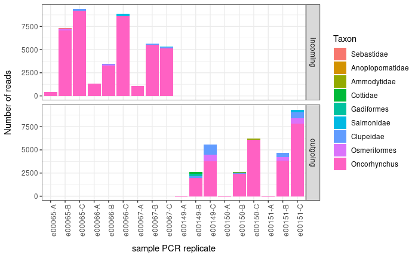

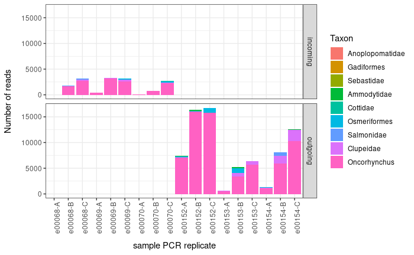

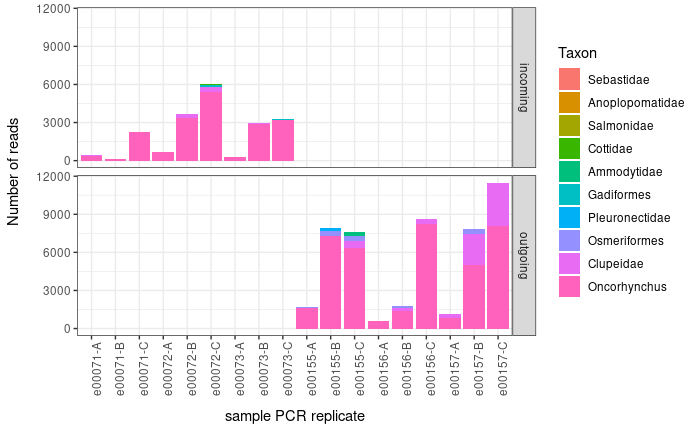

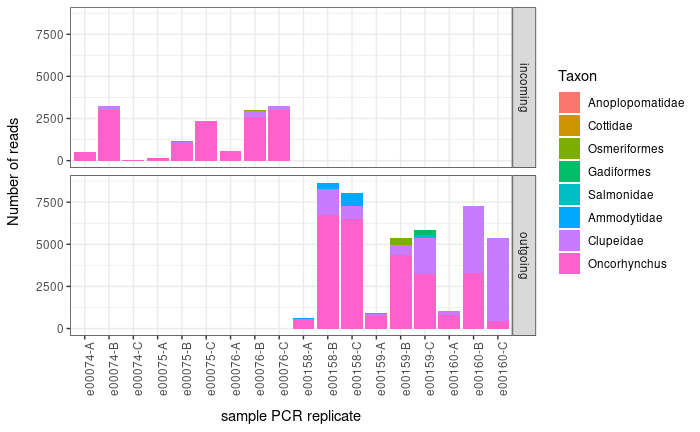

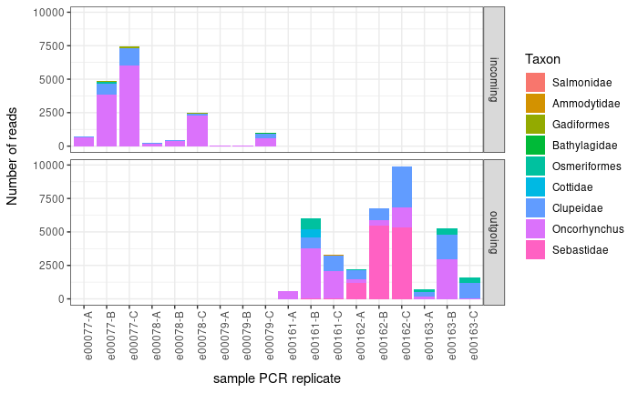

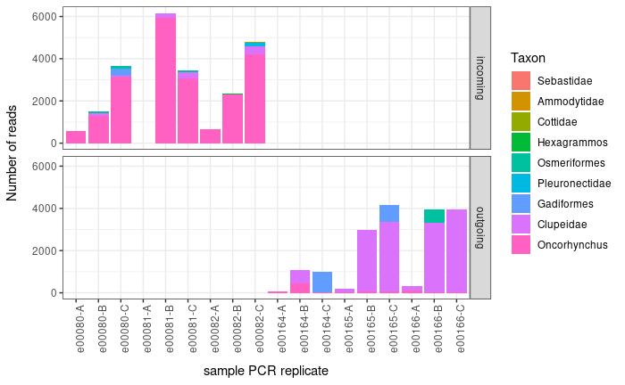

[15 more figures not shown]

```r
# loop over those to take a quick look
lapply(dists, plot_reps)
```

Seems like incoming and outgoing tide also might have some difference in the amount of DNA for some of the samples? Maybe do some read depth summaries by incoming/outgoing tide?

Put another way, if you have greater read depth, do you have more taxa detected? 1) compare across replicates of the same sample 2) compare across replicates of the same distance/tide 3) compare across samples

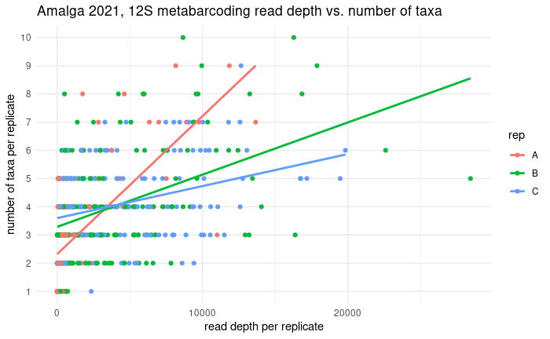

```r
# compare replicates of the same sample
filtered_df_w_metadata %>%
  group_by(sample, rep) %>%
  add_tally(n = "n_taxa_rep") %>%
  group_by(sample, rep, n_taxa_rep) %>%
  summarise(n_reads = sum(count)) %>%
  ggplot(aes(x = n_reads, y = n_taxa_rep, color = rep)) +
  geom_point() +
  geom_smooth(method = "lm", se = F) +
  scale_y_continuous(breaks = seq(0, 10, 1), minor_breaks = NULL) + # make the y-axis logical
theme_minimal() +
  labs(title = "Amalga 2021, 12S metabarcoding read depth vs. number of taxa",
       y = "number of taxa per replicate",
       x = "read depth per replicate")
```

The y-intercept suggests that at low read depth, there are more taxa than would be predicted based on a linear relationship between read depth and number of taxa recovered, but the different slopes for the different replicates suggest that B and C behave much more similarly than A.

[output not shown]

[output cut: 158 more lines]

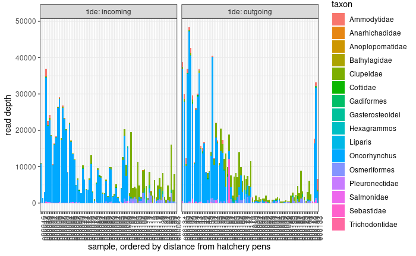

```r
filtered_df_w_metadata %>%
  ungroup() %>%
  select(sample, rep, taxon, count, location, tide, dist_grp) %>%
  group_by(sample, rep, taxon) %>%
  summarise(n_reads = sum(count)) %>%
  left_join(., sample.dist) %>%
  filter(!is.na(tide)) %>%
  ggplot(aes(x = reorder(sample, distance), y = n_reads, fill = taxon)) +
  geom_bar(stat = "identity") +
  facet_grid(cols = vars(tide), scales = "free_x", labeller = "label_both") +
  theme_bw() +
  theme(
    axis.text.x = element_text(angle = 90)
  )  +
  labs(x = "sample, ordered by distance from hatchery pens",
        y = "read depth")
```

Somewhat related question: How much read depth to allocate per sample replicate?

Maximum number of taxa per replicate = 10 Minimum number of taxa per replicate = 1

What is the range for a given sample?

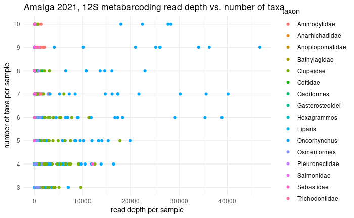

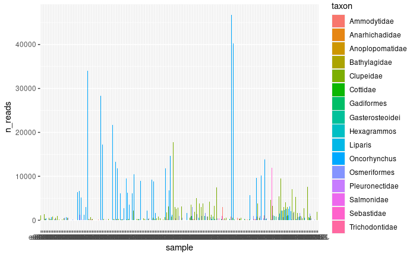

## Presence/absence rather than by read count proportions

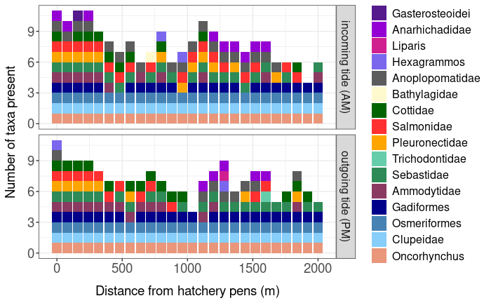

```r
prop.df %>%
    filter(distance > -10) %>%
  mutate(tide = ifelse(tide == "incoming", "incoming tide (AM)", "outgoing tide (PM)")) %>%
  ggplot(aes(distance, fill = reorder(taxon, taxon_prop)))+
  geom_bar(stat="count", position="stack") +
  facet_grid(rows = vars(tide)) +
    theme_bw() +
 theme(
    axis.text.x = element_text(size = 14),
    axis.text.y = element_text(size = 14),
    axis.title.x = element_text(margin = margin(t=10), size = 14),
    axis.title.y = element_text(margin = margin(r=10), size = 14),
    legend.text = element_text(size = 12),
    legend.title = element_blank(),
    strip.text = element_text(size = 12)
    ) +
  labs(y = "Number of taxa present",
       x = "Distance from hatchery pens (m)",
       fill = "Taxon") +
  scale_fill_manual(values = c( 'purple4',"darkviolet", 'violetred', 'slateblue2', "gray36", "lemonchiffon",  'darkgreen', 'firebrick1', "orange1",  'aquamarine3',  'seagreen4', 'hotpink4', "darkblue", 'steelblue','lightskyblue', 'darksalmon'))
# the colors match the other two plots, even though the taxon order has changed.

ggsave("pdf_outputs/12S_taxonPA_v_distance.pdf", width = 9, height = 5)
```

## Revisiting the PCR replicate filter

31 January 2023

Does lower read depth in a given replicate change the species composition of that replicate?

I implemented a filter in “13-pcr-replicate-filtering.Rmd” but now I want to check and see how much of an impact those low-depth replicates actually have?

```r
sample.dist <- filtered_df_w_metadata %>%
  ungroup() %>%
  select(sample, distance) %>%
  unique()
```

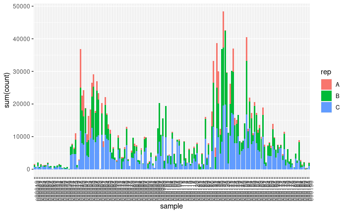

```r
filtered_df_w_metadata %>%
  group_by(sample.PCR, sample, rep) %>%
  summarise(sum(count)) %>%
  left_join(., sample.dist) %>%
  ggplot(aes(x = sample, y = `sum(count)`, fill = rep)) +
  geom_bar(stat = "identity") +
  theme(
    axis.text.x = element_text(angle = 90)
  )
```

```r
NA
NA
NA
NA
NA
```

read depth is all over the place.

Confirm that this plot looks the same as the version with no taxonomy:

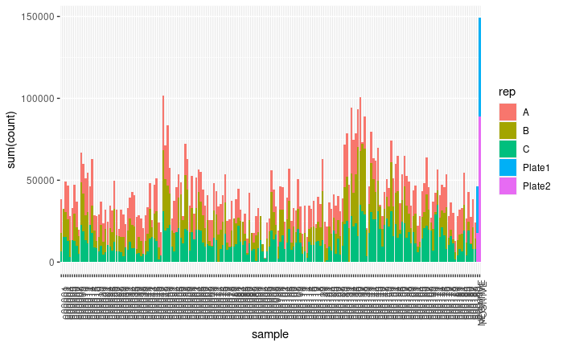

```r
asv_long_tbl %>%
  group_by(sample.PCR, sample, rep) %>%
  summarise(sum(count)) %>%
  ggplot(aes(x = sample, y = `sum(count)`, fill = rep)) +
  geom_bar(stat = "identity") +
  theme(
    axis.text.x = element_text(angle = 90)
  )
```

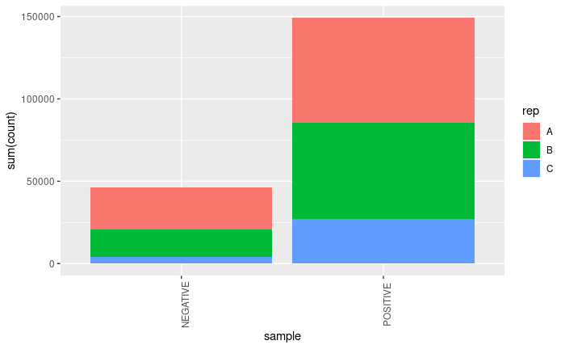

```r
asv_long_tbl %>%
  filter(rep %in% c("Plate1", "Plate2")) %>%
  separate(sample.PCR, into = c("sample", "plate", "rep"), remove = F) %>%
   group_by(sample.PCR, sample, rep) %>%
  summarise(sum(count)) %>%
  ggplot(aes(x = sample, y = `sum(count)`, fill = rep)) +
  geom_bar(stat = "identity") +
  theme(
    axis.text.x = element_text(angle = 90)
  )
```

The controls look wild because all of the reps are combined.

The negative control looks… not great. But those weren’t primarily fish sequences, if I remember correctly.